# POLI 110

March 15, 2019

## Testing Causal Theories

## Plan for Today:

### **(1) Correlation**

- correlation
- confounding (with diagrams)
- reverse causality
- direction of bias
- relationships that are NOT confounding
  - antecedent variables
  - intervening variables

## Correlation

#### **correlation**:

degree of association or relationship between the **observed** values taken by two variables (\(X\) and \(Y\))

- Many different ways of doing this (compare group means, regression) are all fundamentally about correlation.
- correlations have a **direction**:
  - positive: implies that as \(X\) increases, \(Y\) increases
  - negative: \(X\) increases, \(Y\) decreases
- correlations have **strength** (has nothing to do **size of effect**):
  - **strong**: \(X\) and \(Y\) almost **always** move together
  - **weak**: \(X\) and \(Y\) do not move together very much
- There is also a **technical** definition of correlation (later)

## Correlation

To infer causality from correlation, need to know what problems we have to assume are absent

## Confounding (again)

**confounding** occurs when some other variable \(W\) is causally linked to \(X\) (independent variable) *and* \(Y\) (dependent variable).

#### **or if we diagram**

If we diagram causal links between variables using this notation: \(X \to Y\) implies \(X\) causes \(Y\), then…

**confounding** occurs when there is a path between \(X\) and \(Y\) that is **non-causal** (goes the "wrong way" on at least one arrow)

## Confounding (Diagram)

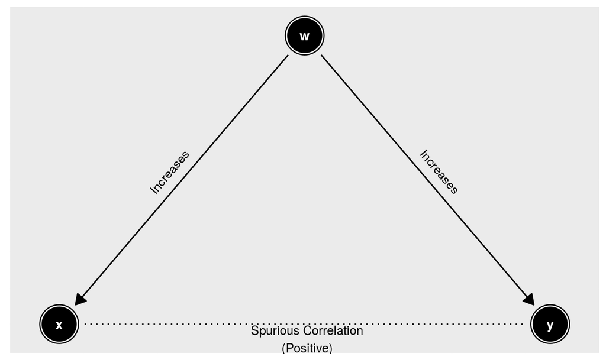

## Correlation: Bias/Confounding?

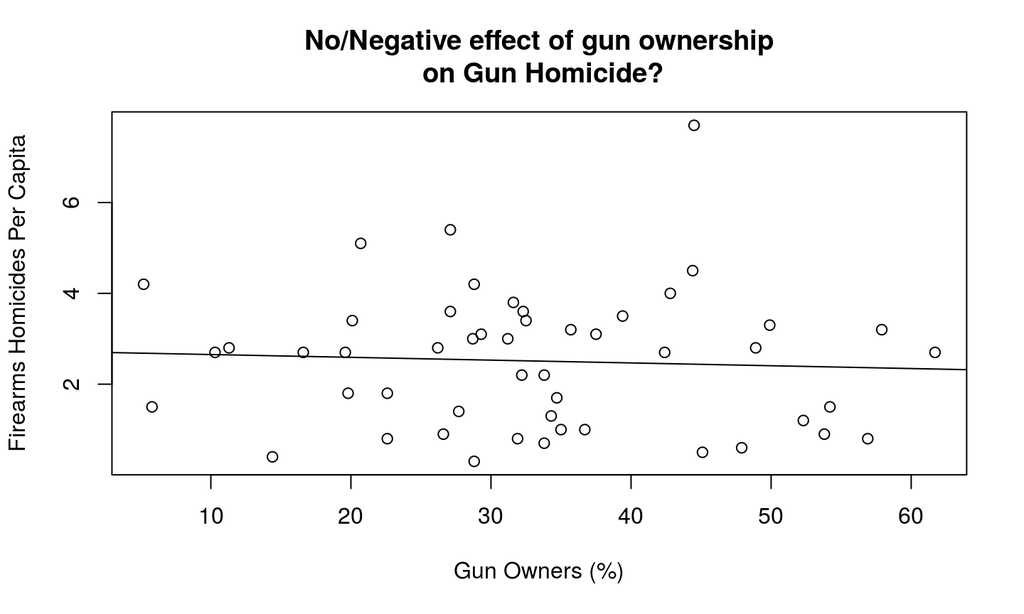

## Confounding (again)

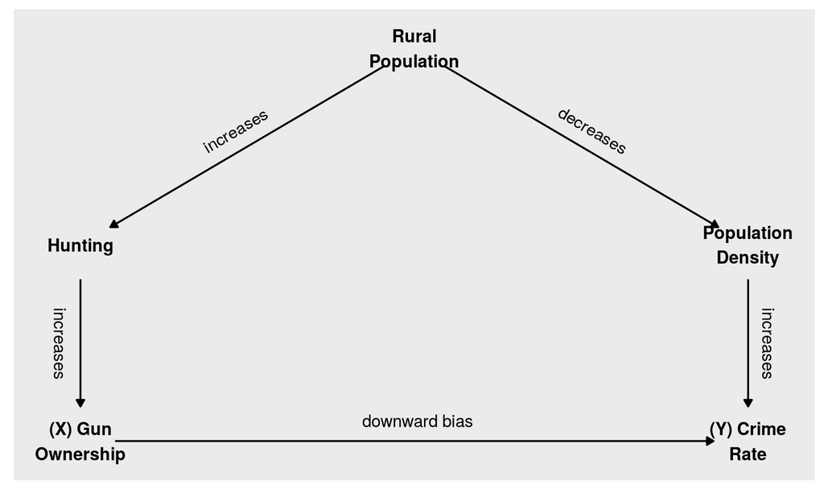

## Confounding (again)

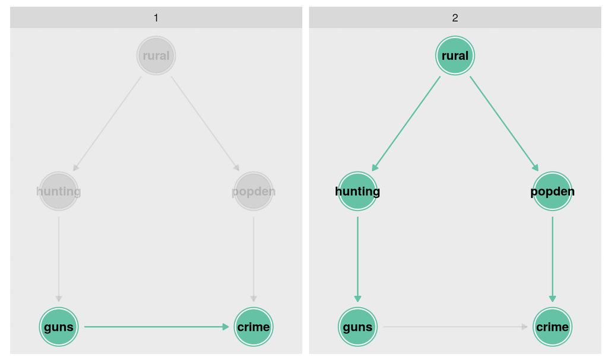

## Confounding: (Another Example)

#### **Causal claim:**

**Anti-refugee hate speech on social media causes anti-refugee violence?**

#### **Causal theory**

hate-speech \(\to\) increase perceived threat \(\to\) decrease acceptance of refugees \(\to\) violence perceived as justified \(\to\) violence

#### **variables**

**IV**: exposure to anti-refugee statements on Facebook; **DV**: incidents of violence against refugees

#### **Hypothesis**

Increase **exposure to anti-refugee content** online associated with increase in **violence against refugees**

## Confounding: (Another Example)

### **Mueller and Schwarz (2018)**

**Test this hypothesis in Germany (2015-2017)**:

- Observe **anti-refugee content** on AfD Facebook page (overtime)
- Observe **anti-refugee violence** reported (overtime)

### What is the correlation?

- Should expect **positive** correlation

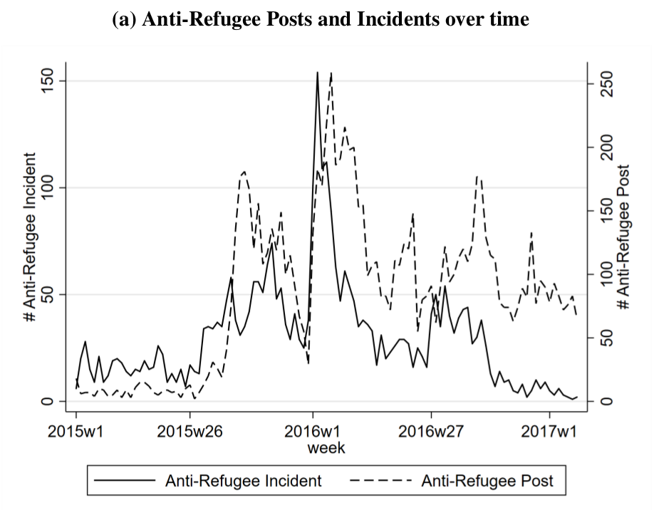

**Are they correlated?**

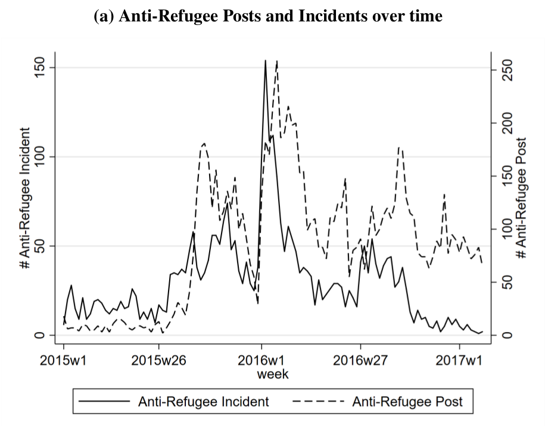

**Can you infer causality?**

## Confounding: (Another Example)

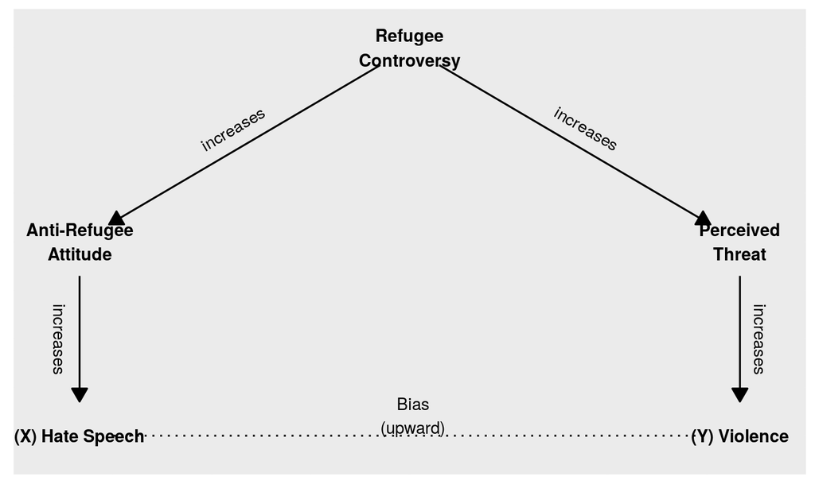

## Confounding: (Another Example)

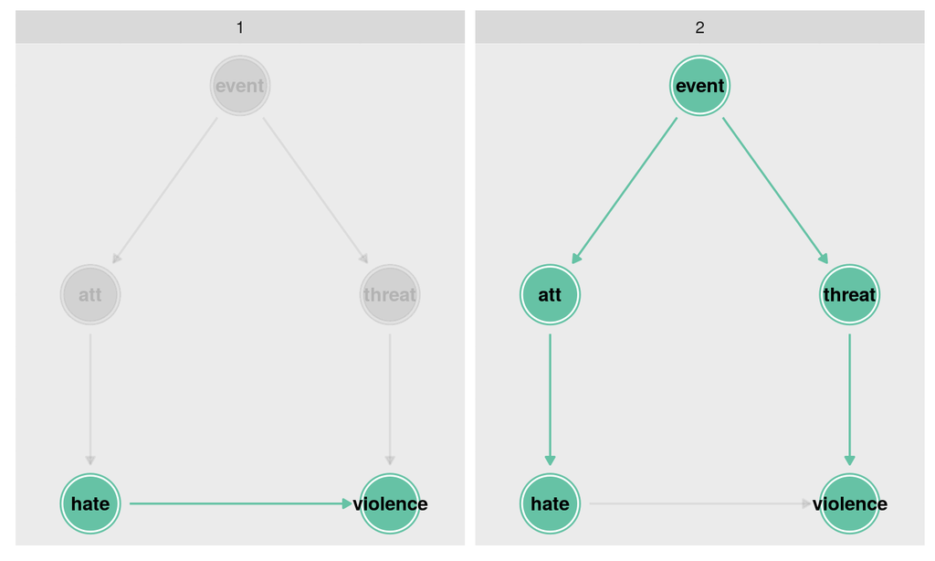

## Confounding: (Reverse Causality)

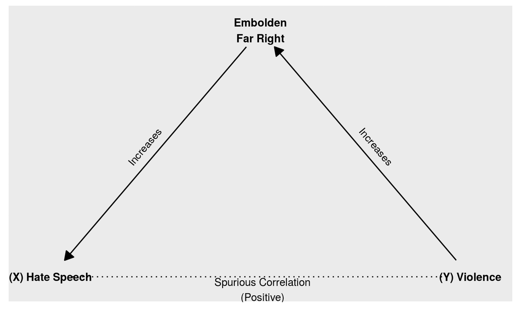

## Reverse Causation

Does \(X\) cause \(Y\)? Or does \(Y\) cause \(X\)

**reverse causation**: bias introduced when our causal theory is that \(X \rightarrow Y\) but in fact \(Y \rightarrow X\)

- Or \(X \rightarrow Y\) **and** \(Y \rightarrow X\)

Why does this happen?

- Causes and effects often **mutually reinforce** each other

## Confounding: Direction of Bias

Product of **signs** on relationships between \(W \to X\), \(W \to Y\) gives us **direction** of **bias** created by **confounding**

|  | \(W \xrightarrow{+} X\) | \(W \xrightarrow{-} X\) |
| --- | --- | --- |
| \(W \xrightarrow{+} Y\) | \(Correlation(X,Y)\) Spurious (+) | \(Correlation(X,Y)\) Spurious (-) |
| \(W \xrightarrow{-} Y\) | \(Correlation(X,Y)\) Spurious (-) | \(Correlation(X,Y)\) Spurious (+) |

## Confounding: Direction of Bias

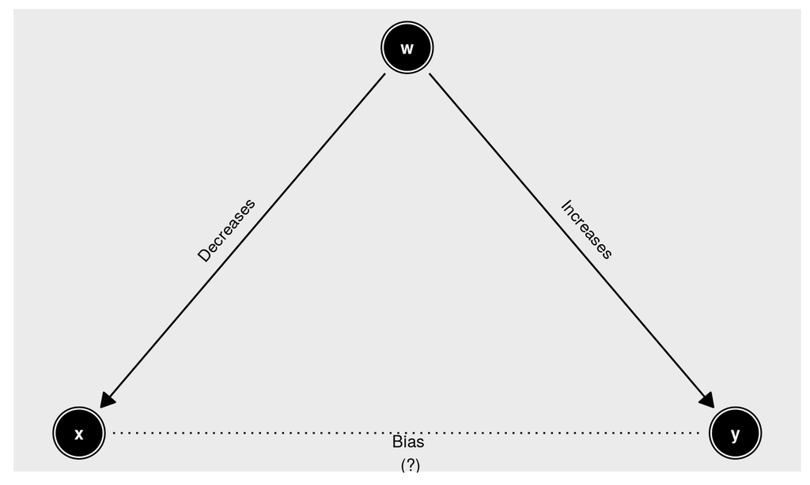

## Confounding: Direction of Bias

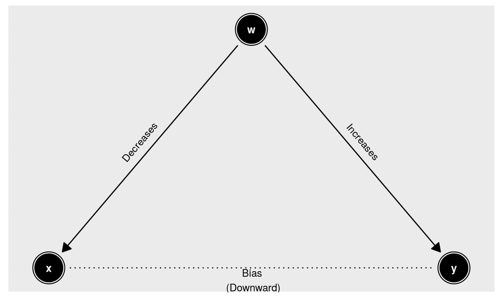

## Confounding: Direction of Bias

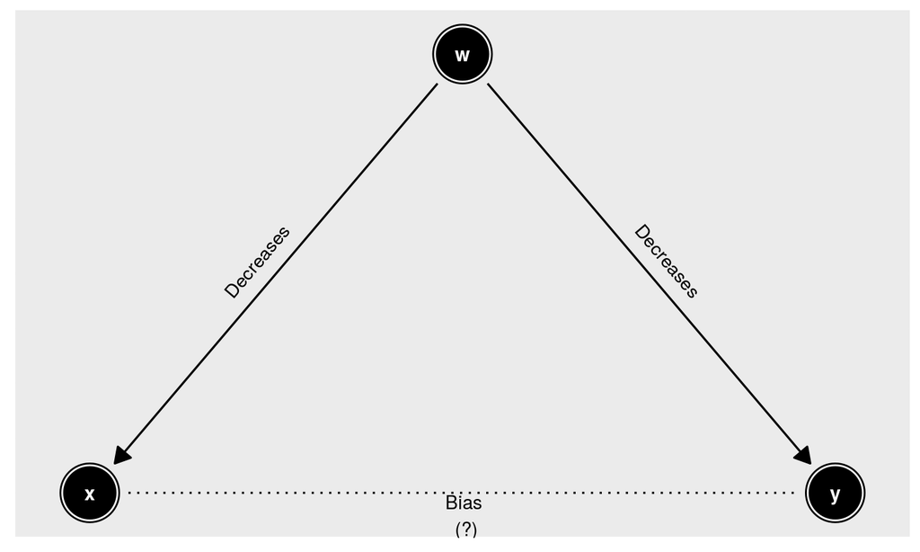

## Confounding: Direction of Bias

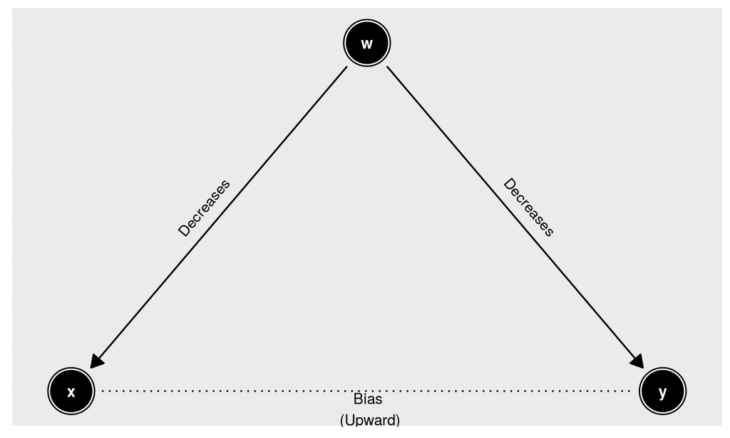

## Confounding: Direction of Bias

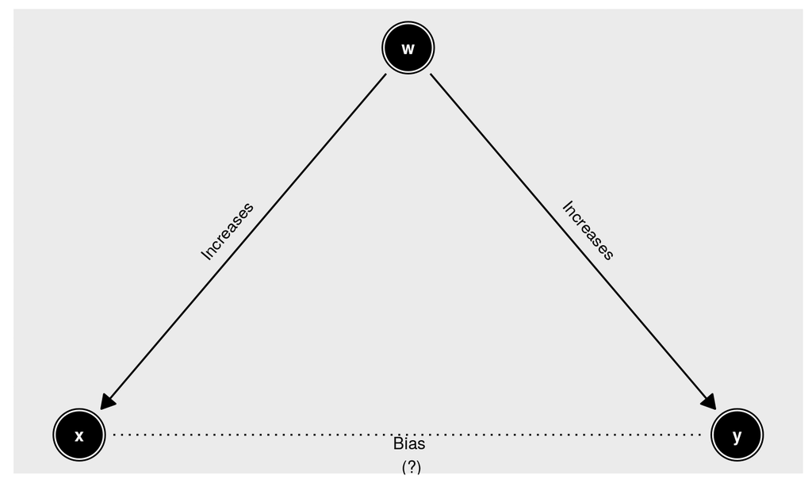

## Confounding: Direction of Bias

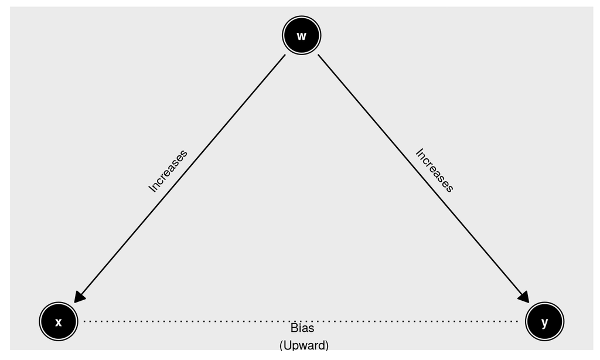

## Not Confounding

**Do *all* third variables create confounding/bias?**

### No.

\(W\) produces no confounding under the following conditions:

1. \(W\) is unrelated to \(X\) or \(Y\)
2. \(W\) is an **antecedent** variable
3. \(W\) is an **intervening** variable

## Confounding (again)

**intervening variable**: a variable **through which** \(X\) causes \(Y\)

- Intervening variables **do not** produce spurious correlations

\[X \rightarrow W \rightarrow Y\]

## Intervening Variable

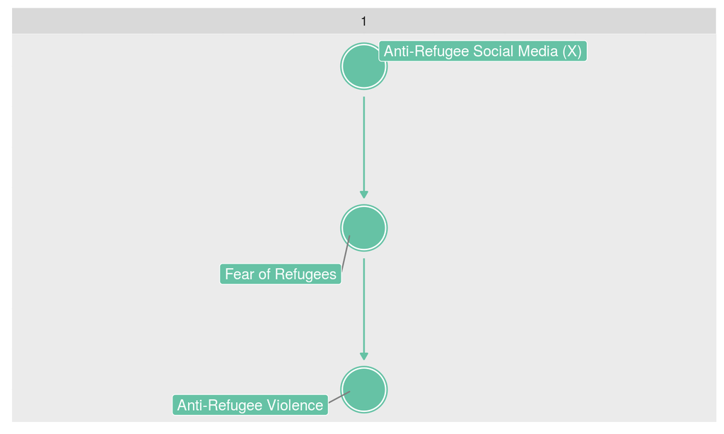

## Antecedent Variable

**antecedent variable**: a variable that **affects** \(Y\) **only through** \(X\)

- antecedent variables **do not** produce spurious correlations if they only affect \(Y\) through \(X\)

\[Z \rightarrow X \rightarrow Y\]

## Antecedent Variable: OK

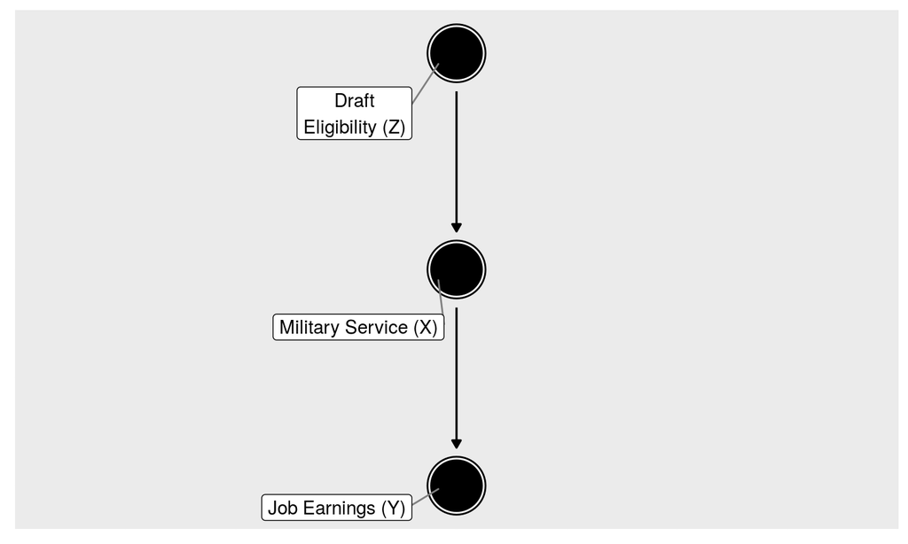

## Antecedent Variable: A Problem

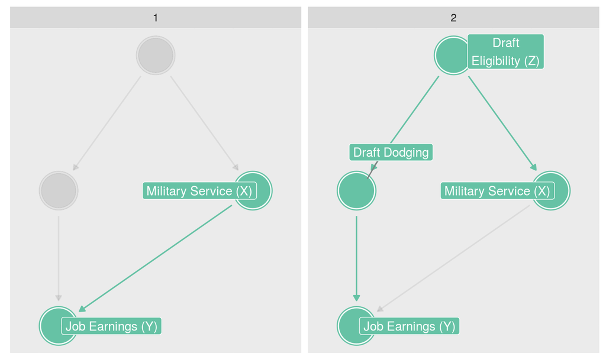

|  | Third Variable? | Bias? |
| --- | --- | --- |
| Confounding | Yes | Yes |
| Antecedent Variables | Yes | No If only **one path** |
| Intervening Variables | Yes | No |
| Reverse Causality | No | Yes |

## Next Time: